# Final Project Fall 2024 - MQari

Mubashira Qari

2024-03-24

### Advanced Regression Techniques competition

### Load the Libraries

```r
library(tidyverse)
library(readr)
library(lmtest)
library(ggpubr)
library(broom)
library(ggfortify)
library(skimr)
```

```r
library(ggplot2)
```

### Import R Dataset from GitHub

```r
urlfile1<- "https://raw.githubusercontent.com/uzmabb182/Data605_Assignment/main/datasets/train.csv"

urlfile2<- "https://raw.githubusercontent.com/tiwari91/Housing-Prices/master/test.csv"

train_df<-read_csv(url(urlfile1))
test_df<-read_csv(url(urlfile2))
head(train_df)
```

```
## # A tibble: 6 × 81
##      Id MSSubClass MSZoning LotFrontage LotArea Street Alley LotShape
##   <dbl>      <dbl> <chr>          <dbl>   <dbl> <chr>  <chr> <chr>
## 1     1         60 RL                65    8450 Pave   <NA>  Reg
## 2     2         20 RL                80    9600 Pave   <NA>  Reg
## 3     3         60 RL                68   11250 Pave   <NA>  IR1
## 4     4         70 RL                60    9550 Pave   <NA>  IR1
## 5     5         60 RL                84   14260 Pave   <NA>  IR1
## 6     6         50 RL                85   14115 Pave   <NA>  IR1
## # ℹ 73 more variables: LandContour <chr>, Utilities <chr>, LotConfig <chr>,
## #   LandSlope <chr>, Neighborhood <chr>, Condition1 <chr>, Condition2 <chr>,
## #   BldgType <chr>, HouseStyle <chr>, OverallQual <dbl>, OverallCond <dbl>,
## #   YearBuilt <dbl>, YearRemodAdd <dbl>, RoofStyle <chr>, RoofMatl <chr>,
## #   Exterior1st <chr>, Exterior2nd <chr>, MasVnrType <chr>, MasVnrArea <dbl>,
## #   ExterQual <chr>, ExterCond <chr>, Foundation <chr>, BsmtQual <chr>,
## #   BsmtCond <chr>, BsmtExposure <chr>, BsmtFinType1 <chr>, BsmtFinSF1 <dbl>, …
```

### View and Check Dimensions.

```r
#view(train_df)
```

```r
dim(train_df)
```

```
## [1] 1460   81
```

### Check Column Names.

```r
names(train_df)
```

```
##  [1] "Id"            "MSSubClass"    "MSZoning"      "LotFrontage"
##  [5] "LotArea"       "Street"        "Alley"         "LotShape"
##  [9] "LandContour"   "Utilities"     "LotConfig"     "LandSlope"
## [13] "Neighborhood"  "Condition1"    "Condition2"    "BldgType"
## [17] "HouseStyle"    "OverallQual"   "OverallCond"   "YearBuilt"
## [21] "YearRemodAdd"  "RoofStyle"     "RoofMatl"      "Exterior1st"
## [25] "Exterior2nd"   "MasVnrType"    "MasVnrArea"    "ExterQual"
## [29] "ExterCond"     "Foundation"    "BsmtQual"      "BsmtCond"
## [33] "BsmtExposure"  "BsmtFinType1"  "BsmtFinSF1"    "BsmtFinType2"
## [37] "BsmtFinSF2"    "BsmtUnfSF"     "TotalBsmtSF"   "Heating"
## [41] "HeatingQC"     "CentralAir"    "Electrical"    "1stFlrSF"
## [45] "2ndFlrSF"      "LowQualFinSF"  "GrLivArea"     "BsmtFullBath"
## [49] "BsmtHalfBath"  "FullBath"      "HalfBath"      "BedroomAbvGr"
## [53] "KitchenAbvGr"  "KitchenQual"   "TotRmsAbvGrd"  "Functional"
## [57] "Fireplaces"    "FireplaceQu"   "GarageType"    "GarageYrBlt"
## [61] "GarageFinish"  "GarageCars"    "GarageArea"    "GarageQual"
## [65] "GarageCond"    "PavedDrive"    "WoodDeckSF"    "OpenPorchSF"
## [69] "EnclosedPorch" "3SsnPorch"     "ScreenPorch"   "PoolArea"
## [73] "PoolQC"        "Fence"         "MiscFeature"   "MiscVal"
## [77] "MoSold"        "YrSold"        "SaleType"      "SaleCondition"
## [81] "SalePrice"
```

### Check Internal Structure of the Data Frame

```r
glimpse(train_df)
```

```
## Rows: 1,460
## Columns: 81
## $ Id            <dbl> 1, 2, 3, 4, 5, 6, 7, 8, 9, 10, 11, 12, 13, 14, 15, 16, 1…
## $ MSSubClass    <dbl> 60, 20, 60, 70, 60, 50, 20, 60, 50, 190, 20, 60, 20, 20,…
## $ MSZoning      <chr> "RL", "RL", "RL", "RL", "RL", "RL", "RL", "RL", "RM", "R…
## $ LotFrontage   <dbl> 65, 80, 68, 60, 84, 85, 75, NA, 51, 50, 70, 85, NA, 91, …
## $ LotArea       <dbl> 8450, 9600, 11250, 9550, 14260, 14115, 10084, 10382, 612…
## $ Street        <chr> "Pave", "Pave", "Pave", "Pave", "Pave", "Pave", "Pave", …
## $ Alley         <chr> NA, NA, NA, NA, NA, NA, NA, NA, NA, NA, NA, NA, NA, NA, …
## $ LotShape      <chr> "Reg", "Reg", "IR1", "IR1", "IR1", "IR1", "Reg", "IR1", …
## $ LandContour   <chr> "Lvl", "Lvl", "Lvl", "Lvl", "Lvl", "Lvl", "Lvl", "Lvl", …
## $ Utilities     <chr> "AllPub", "AllPub", "AllPub", "AllPub", "AllPub", "AllPu…
## $ LotConfig     <chr> "Inside", "FR2", "Inside", "Corner", "FR2", "Inside", "I…
## $ LandSlope     <chr> "Gtl", "Gtl", "Gtl", "Gtl", "Gtl", "Gtl", "Gtl", "Gtl", …
## $ Neighborhood  <chr> "CollgCr", "Veenker", "CollgCr", "Crawfor", "NoRidge", "…
```

[output cut: 68 more lines]

### Getting Useful Summary Statistics

```r
skim(train_df)
```

Data summary

| Name | train_df |
| --- | --- |
| Number of rows | 1460 |
| Number of columns | 81 |
| _______________________ |  |
| Column type frequency: |  |
| character | 43 |
| numeric | 38 |
| ________________________ |  |
| Group variables | None |

**Variable type: character**

| skim_variable | n_missing | complete_rate | min | max | empty | n_unique | whitespace |
| --- | --- | --- | --- | --- | --- | --- | --- |
| MSZoning | 0 | 1.00 | 2 | 7 | 0 | 5 | 0 |
| Street | 0 | 1.00 | 4 | 4 | 0 | 2 | 0 |
| Alley | 1369 | 0.06 | 4 | 4 | 0 | 2 | 0 |
| LotShape | 0 | 1.00 | 3 | 3 | 0 | 4 | 0 |
| LandContour | 0 | 1.00 | 3 | 3 | 0 | 4 | 0 |
| Utilities | 0 | 1.00 | 6 | 6 | 0 | 2 | 0 |
| LotConfig | 0 | 1.00 | 3 | 7 | 0 | 5 | 0 |
| LandSlope | 0 | 1.00 | 3 | 3 | 0 | 3 | 0 |
| Neighborhood | 0 | 1.00 | 5 | 7 | 0 | 25 | 0 |
| Condition1 | 0 | 1.00 | 4 | 6 | 0 | 9 | 0 |
| Condition2 | 0 | 1.00 | 4 | 6 | 0 | 8 | 0 |
| BldgType | 0 | 1.00 | 4 | 6 | 0 | 5 | 0 |
| HouseStyle | 0 | 1.00 | 4 | 6 | 0 | 8 | 0 |
| RoofStyle | 0 | 1.00 | 3 | 7 | 0 | 6 | 0 |
| RoofMatl | 0 | 1.00 | 4 | 7 | 0 | 8 | 0 |
| Exterior1st | 0 | 1.00 | 5 | 7 | 0 | 15 | 0 |
| Exterior2nd | 0 | 1.00 | 5 | 7 | 0 | 16 | 0 |
| MasVnrType | 8 | 0.99 | 4 | 7 | 0 | 4 | 0 |
| ExterQual | 0 | 1.00 | 2 | 2 | 0 | 4 | 0 |
| ExterCond | 0 | 1.00 | 2 | 2 | 0 | 5 | 0 |
| Foundation | 0 | 1.00 | 4 | 6 | 0 | 6 | 0 |
| BsmtQual | 37 | 0.97 | 2 | 2 | 0 | 4 | 0 |
| BsmtCond | 37 | 0.97 | 2 | 2 | 0 | 4 | 0 |
| BsmtExposure | 38 | 0.97 | 2 | 2 | 0 | 4 | 0 |
| BsmtFinType1 | 37 | 0.97 | 3 | 3 | 0 | 6 | 0 |
| BsmtFinType2 | 38 | 0.97 | 3 | 3 | 0 | 6 | 0 |
| Heating | 0 | 1.00 | 4 | 5 | 0 | 6 | 0 |
| HeatingQC | 0 | 1.00 | 2 | 2 | 0 | 5 | 0 |
| CentralAir | 0 | 1.00 | 1 | 1 | 0 | 2 | 0 |
| Electrical | 1 | 1.00 | 3 | 5 | 0 | 5 | 0 |
| KitchenQual | 0 | 1.00 | 2 | 2 | 0 | 4 | 0 |
| Functional | 0 | 1.00 | 3 | 4 | 0 | 7 | 0 |
| FireplaceQu | 690 | 0.53 | 2 | 2 | 0 | 5 | 0 |
| GarageType | 81 | 0.94 | 6 | 7 | 0 | 6 | 0 |
| GarageFinish | 81 | 0.94 | 3 | 3 | 0 | 3 | 0 |
| GarageQual | 81 | 0.94 | 2 | 2 | 0 | 5 | 0 |
| GarageCond | 81 | 0.94 | 2 | 2 | 0 | 5 | 0 |
| PavedDrive | 0 | 1.00 | 1 | 1 | 0 | 3 | 0 |
| PoolQC | 1453 | 0.00 | 2 | 2 | 0 | 3 | 0 |
| Fence | 1179 | 0.19 | 4 | 5 | 0 | 4 | 0 |
| MiscFeature | 1406 | 0.04 | 4 | 4 | 0 | 4 | 0 |
| SaleType | 0 | 1.00 | 2 | 5 | 0 | 9 | 0 |
| SaleCondition | 0 | 1.00 | 6 | 7 | 0 | 6 | 0 |

**Variable type: numeric**

| skim_variable | n_missing | complete_rate | mean | sd | p0 | p25 | p50 | p75 | p100 | hist |
| --- | --- | --- | --- | --- | --- | --- | --- | --- | --- | --- |
| Id | 0 | 1.00 | 730.50 | 421.61 | 1 | 365.75 | 730.5 | 1095.25 | 1460 | ▇▇▇▇▇ |
| MSSubClass | 0 | 1.00 | 56.90 | 42.30 | 20 | 20.00 | 50.0 | 70.00 | 190 | ▇▅▂▁▁ |
| LotFrontage | 259 | 0.82 | 70.05 | 24.28 | 21 | 59.00 | 69.0 | 80.00 | 313 | ▇▃▁▁▁ |
| LotArea | 0 | 1.00 | 10516.83 | 9981.26 | 1300 | 7553.50 | 9478.5 | 11601.50 | 215245 | ▇▁▁▁▁ |
| OverallQual | 0 | 1.00 | 6.10 | 1.38 | 1 | 5.00 | 6.0 | 7.00 | 10 | ▁▂▇▅▁ |
| OverallCond | 0 | 1.00 | 5.58 | 1.11 | 1 | 5.00 | 5.0 | 6.00 | 9 | ▁▁▇▅▁ |
| YearBuilt | 0 | 1.00 | 1971.27 | 30.20 | 1872 | 1954.00 | 1973.0 | 2000.00 | 2010 | ▁▂▃▆▇ |
| YearRemodAdd | 0 | 1.00 | 1984.87 | 20.65 | 1950 | 1967.00 | 1994.0 | 2004.00 | 2010 | ▅▂▂▃▇ |
| MasVnrArea | 8 | 0.99 | 103.69 | 181.07 | 0 | 0.00 | 0.0 | 166.00 | 1600 | ▇▁▁▁▁ |
| BsmtFinSF1 | 0 | 1.00 | 443.64 | 456.10 | 0 | 0.00 | 383.5 | 712.25 | 5644 | ▇▁▁▁▁ |
| BsmtFinSF2 | 0 | 1.00 | 46.55 | 161.32 | 0 | 0.00 | 0.0 | 0.00 | 1474 | ▇▁▁▁▁ |
| BsmtUnfSF | 0 | 1.00 | 567.24 | 441.87 | 0 | 223.00 | 477.5 | 808.00 | 2336 | ▇▅▂▁▁ |
| TotalBsmtSF | 0 | 1.00 | 1057.43 | 438.71 | 0 | 795.75 | 991.5 | 1298.25 | 6110 | ▇▃▁▁▁ |
| 1stFlrSF | 0 | 1.00 | 1162.63 | 386.59 | 334 | 882.00 | 1087.0 | 1391.25 | 4692 | ▇▅▁▁▁ |
| 2ndFlrSF | 0 | 1.00 | 346.99 | 436.53 | 0 | 0.00 | 0.0 | 728.00 | 2065 | ▇▃▂▁▁ |
| LowQualFinSF | 0 | 1.00 | 5.84 | 48.62 | 0 | 0.00 | 0.0 | 0.00 | 572 | ▇▁▁▁▁ |
| GrLivArea | 0 | 1.00 | 1515.46 | 525.48 | 334 | 1129.50 | 1464.0 | 1776.75 | 5642 | ▇▇▁▁▁ |
| BsmtFullBath | 0 | 1.00 | 0.43 | 0.52 | 0 | 0.00 | 0.0 | 1.00 | 3 | ▇▆▁▁▁ |
| BsmtHalfBath | 0 | 1.00 | 0.06 | 0.24 | 0 | 0.00 | 0.0 | 0.00 | 2 | ▇▁▁▁▁ |
| FullBath | 0 | 1.00 | 1.57 | 0.55 | 0 | 1.00 | 2.0 | 2.00 | 3 | ▁▇▁▇▁ |
| HalfBath | 0 | 1.00 | 0.38 | 0.50 | 0 | 0.00 | 0.0 | 1.00 | 2 | ▇▁▅▁▁ |
| BedroomAbvGr | 0 | 1.00 | 2.87 | 0.82 | 0 | 2.00 | 3.0 | 3.00 | 8 | ▁▇▂▁▁ |
| KitchenAbvGr | 0 | 1.00 | 1.05 | 0.22 | 0 | 1.00 | 1.0 | 1.00 | 3 | ▁▇▁▁▁ |
| TotRmsAbvGrd | 0 | 1.00 | 6.52 | 1.63 | 2 | 5.00 | 6.0 | 7.00 | 14 | ▂▇▇▁▁ |
| Fireplaces | 0 | 1.00 | 0.61 | 0.64 | 0 | 0.00 | 1.0 | 1.00 | 3 | ▇▇▁▁▁ |
| GarageYrBlt | 81 | 0.94 | 1978.51 | 24.69 | 1900 | 1961.00 | 1980.0 | 2002.00 | 2010 | ▁▁▅▅▇ |
| GarageCars | 0 | 1.00 | 1.77 | 0.75 | 0 | 1.00 | 2.0 | 2.00 | 4 | ▁▃▇▂▁ |
| GarageArea | 0 | 1.00 | 472.98 | 213.80 | 0 | 334.50 | 480.0 | 576.00 | 1418 | ▂▇▃▁▁ |
| WoodDeckSF | 0 | 1.00 | 94.24 | 125.34 | 0 | 0.00 | 0.0 | 168.00 | 857 | ▇▂▁▁▁ |
| OpenPorchSF | 0 | 1.00 | 46.66 | 66.26 | 0 | 0.00 | 25.0 | 68.00 | 547 | ▇▁▁▁▁ |
| EnclosedPorch | 0 | 1.00 | 21.95 | 61.12 | 0 | 0.00 | 0.0 | 0.00 | 552 | ▇▁▁▁▁ |
| 3SsnPorch | 0 | 1.00 | 3.41 | 29.32 | 0 | 0.00 | 0.0 | 0.00 | 508 | ▇▁▁▁▁ |
| ScreenPorch | 0 | 1.00 | 15.06 | 55.76 | 0 | 0.00 | 0.0 | 0.00 | 480 | ▇▁▁▁▁ |
| PoolArea | 0 | 1.00 | 2.76 | 40.18 | 0 | 0.00 | 0.0 | 0.00 | 738 | ▇▁▁▁▁ |
| MiscVal | 0 | 1.00 | 43.49 | 496.12 | 0 | 0.00 | 0.0 | 0.00 | 15500 | ▇▁▁▁▁ |
| MoSold | 0 | 1.00 | 6.32 | 2.70 | 1 | 5.00 | 6.0 | 8.00 | 12 | ▃▆▇▃▃ |
| YrSold | 0 | 1.00 | 2007.82 | 1.33 | 2006 | 2007.00 | 2008.0 | 2009.00 | 2010 | ▇▇▇▇▅ |
| SalePrice | 0 | 1.00 | 180921.20 | 79442.50 | 34900 | 129975.00 | 163000.0 | 214000.00 | 755000 | ▇▅▁▁▁ |

### To Investigate the Datatypes of Coumns.

```r
str(train_df)
```

```
## spc_tbl_ [1,460 × 81] (S3: spec_tbl_df/tbl_df/tbl/data.frame)
##  $ Id           : num [1:1460] 1 2 3 4 5 6 7 8 9 10 ...
##  $ MSSubClass   : num [1:1460] 60 20 60 70 60 50 20 60 50 190 ...
##  $ MSZoning     : chr [1:1460] "RL" "RL" "RL" "RL" ...
##  $ LotFrontage  : num [1:1460] 65 80 68 60 84 85 75 NA 51 50 ...
##  $ LotArea      : num [1:1460] 8450 9600 11250 9550 14260 ...
##  $ Street       : chr [1:1460] "Pave" "Pave" "Pave" "Pave" ...
##  $ Alley        : chr [1:1460] NA NA NA NA ...
##  $ LotShape     : chr [1:1460] "Reg" "Reg" "IR1" "IR1" ...
##  $ LandContour  : chr [1:1460] "Lvl" "Lvl" "Lvl" "Lvl" ...
##  $ Utilities    : chr [1:1460] "AllPub" "AllPub" "AllPub" "AllPub" ...
##  $ LotConfig    : chr [1:1460] "Inside" "FR2" "Inside" "Corner" ...
##  $ LandSlope    : chr [1:1460] "Gtl" "Gtl" "Gtl" "Gtl" ...
##  $ Neighborhood : chr [1:1460] "CollgCr" "Veenker" "CollgCr" "Crawfor" ...
##  $ Condition1   : chr [1:1460] "Norm" "Feedr" "Norm" "Norm" ...
##  $ Condition2   : chr [1:1460] "Norm" "Norm" "Norm" "Norm" ...
##  $ BldgType     : chr [1:1460] "1Fam" "1Fam" "1Fam" "1Fam" ...
##  $ HouseStyle   : chr [1:1460] "2Story" "1Story" "2Story" "2Story" ...
##  $ OverallQual  : num [1:1460] 7 6 7 7 8 5 8 7 7 5 ...
##  $ OverallCond  : num [1:1460] 5 8 5 5 5 5 5 6 5 6 ...
##  $ YearBuilt    : num [1:1460] 2003 1976 2001 1915 2000 ...
##  $ YearRemodAdd : num [1:1460] 2003 1976 2002 1970 2000 ...
##  $ RoofStyle    : chr [1:1460] "Gable" "Gable" "Gable" "Gable" ...
##  $ RoofMatl     : chr [1:1460] "CompShg" "CompShg" "CompShg" "CompShg" ...
##  $ Exterior1st  : chr [1:1460] "VinylSd" "MetalSd" "VinylSd" "Wd Sdng" ...
##  $ Exterior2nd  : chr [1:1460] "VinylSd" "MetalSd" "VinylSd" "Wd Shng" ...
##  $ MasVnrType   : chr [1:1460] "BrkFace" "None" "BrkFace" "None" ...
##  $ MasVnrArea   : num [1:1460] 196 0 162 0 350 0 186 240 0 0 ...
##  $ ExterQual    : chr [1:1460] "Gd" "TA" "Gd" "TA" ...
##  $ ExterCond    : chr [1:1460] "TA" "TA" "TA" "TA" ...
##  $ Foundation   : chr [1:1460] "PConc" "CBlock" "PConc" "BrkTil" ...
##  $ BsmtQual     : chr [1:1460] "Gd" "Gd" "Gd" "TA" ...
##  $ BsmtCond     : chr [1:1460] "TA" "TA" "TA" "Gd" ...
##  $ BsmtExposure : chr [1:1460] "No" "Gd" "Mn" "No" ...
##  $ BsmtFinType1 : chr [1:1460] "GLQ" "ALQ" "GLQ" "ALQ" ...
##  $ BsmtFinSF1   : num [1:1460] 706 978 486 216 655 ...
##  $ BsmtFinType2 : chr [1:1460] "Unf" "Unf" "Unf" "Unf" ...
##  $ BsmtFinSF2   : num [1:1460] 0 0 0 0 0 0 0 32 0 0 ...
##  $ BsmtUnfSF    : num [1:1460] 150 284 434 540 490 64 317 216 952 140 ...
##  $ TotalBsmtSF  : num [1:1460] 856 1262 920 756 1145 ...
```

[output cut: 112 more lines]

```
##   ..   EnclosedPorch = col_double(),
##   ..   `3SsnPorch` = col_double(),
##   ..   ScreenPorch = col_double(),
##   ..   PoolArea = col_double(),
##   ..   PoolQC = col_character(),
##   ..   Fence = col_character(),
##   ..   MiscFeature = col_character(),
##   ..   MiscVal = col_double(),
##   ..   MoSold = col_double(),
##   ..   YrSold = col_double(),
##   ..   SaleType = col_character(),
##   ..   SaleCondition = col_character(),
##   ..   SalePrice = col_double()
##   .. )
##  - attr(*, "problems")=<externalptr>
```

### Drop the Columns with NAs

```r
train_df <- subset(train_df, select = -c(Alley, PoolQC, Fence, MiscFeature, FireplaceQu))
str(train_df)
```

```
## tibble [1,460 × 76] (S3: tbl_df/tbl/data.frame)
##  $ Id           : num [1:1460] 1 2 3 4 5 6 7 8 9 10 ...
##  $ MSSubClass   : num [1:1460] 60 20 60 70 60 50 20 60 50 190 ...
##  $ MSZoning     : chr [1:1460] "RL" "RL" "RL" "RL" ...
##  $ LotFrontage  : num [1:1460] 65 80 68 60 84 85 75 NA 51 50 ...
##  $ LotArea      : num [1:1460] 8450 9600 11250 9550 14260 ...
##  $ Street       : chr [1:1460] "Pave" "Pave" "Pave" "Pave" ...
##  $ LotShape     : chr [1:1460] "Reg" "Reg" "IR1" "IR1" ...
##  $ LandContour  : chr [1:1460] "Lvl" "Lvl" "Lvl" "Lvl" ...
##  $ Utilities    : chr [1:1460] "AllPub" "AllPub" "AllPub" "AllPub" ...
##  $ LotConfig    : chr [1:1460] "Inside" "FR2" "Inside" "Corner" ...
##  $ LandSlope    : chr [1:1460] "Gtl" "Gtl" "Gtl" "Gtl" ...
##  $ Neighborhood : chr [1:1460] "CollgCr" "Veenker" "CollgCr" "Crawfor" ...
##  $ Condition1   : chr [1:1460] "Norm" "Feedr" "Norm" "Norm" ...
##  $ Condition2   : chr [1:1460] "Norm" "Norm" "Norm" "Norm" ...
```

[output cut: 62 more lines]

```r
sum(is.na(train_df))
```

```
## [1] 868
```

### Pick an Independent Variable with Right-Skewness.

Pick one of the quantitative independent variables from the training data set (train.csv) , and define that variable as X.

Make sure this variable is skewed to the right! Pick the dependent variable and define it as Y.

```r
x <- train_df$OverallQual
```

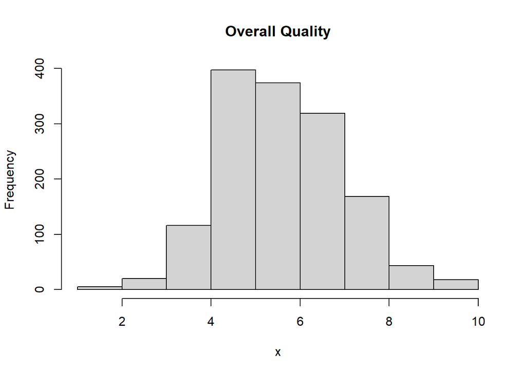

```r
hist(x, main = "Overall Quality")
```

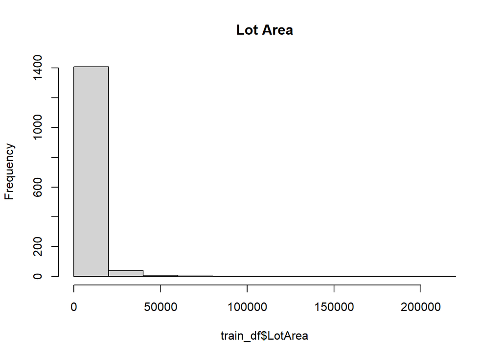

```r
x <- train_df$LotArea

hist(train_df$LotArea, main = "Lot Area")
```

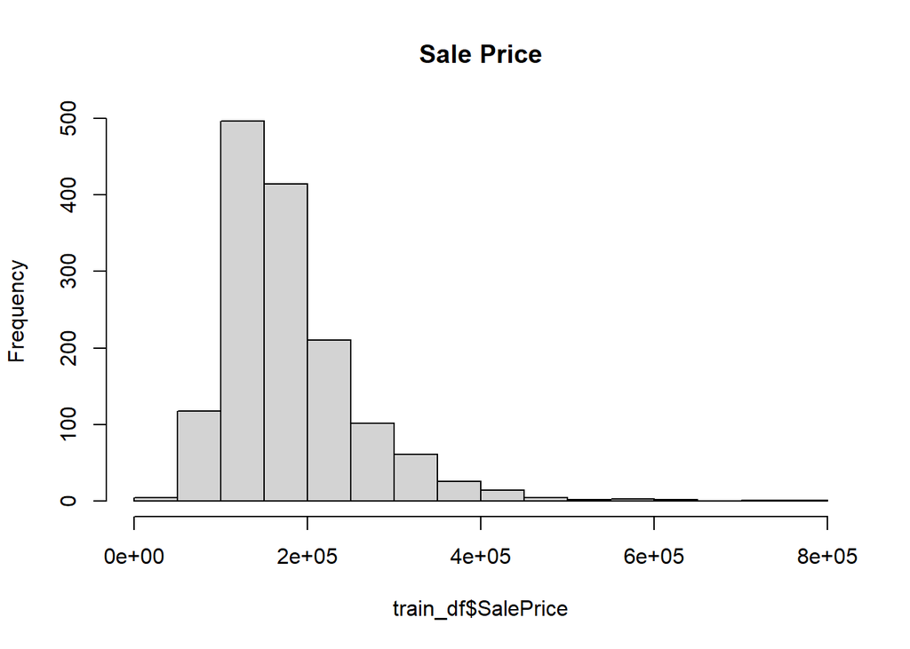

```r
# LotArea is clearly right-skewed.
X = train_df$LotArea

# The target variable we are trying to predict is SalePrice, the
# property's sale price in dollars.

Y = train_df$SalePrice

# Show histogram of SalePrice (target).
# SalePrice
hist(train_df$SalePrice, main = "Sale Price")
```

### Probability.

Calculate as a minimum the below probabilities a through c. Assume the small letter “x” is estimated as the 3d quartile of the X variable, and the small letter “y” is estimated as the 2d quartile of the Y variable. Interpret the meaning of all probabilities. In addition, make a table of counts as shown below.

1. P(X>x | Y>y) b. P(X>x, Y>y) c. P(X<x | Y>y)

### Summarize X (independent var.) and Y (target)

Pipe the data frame into the select() function from the dplyr package in R

```r
df = train_df %>% dplyr::select(LotArea, SalePrice)
summary(df)
```

```
##     LotArea         SalePrice
##  Min.   :  1300   Min.   : 34900
##  1st Qu.:  7554   1st Qu.:129975
##  Median :  9478   Median :163000
##  Mean   : 10517   Mean   :180921
##  3rd Qu.: 11602   3rd Qu.:214000
##  Max.   :215245   Max.   :755000
```

The meaning of all these probabilities:

1. means the probability of the LotArea being bigger tham the first quartile, given the SalePrice is bigger than the first Quartile.
2. means that the probability of both scenarios happening.
3. means the probability that the lotArea is smaller than the 1st quartile given that the SalePrice is bigger than the first quartile

```r
#Assign quartile values to variables.
XQ1<-quantile(train_df$LotArea, 0.25)
YQ1<-quantile(train_df$SalePrice, 0.25)

#Create subsets of data based on quartile operators.
yY <- subset(train_df,SalePrice <= YQ1)
Yy <- subset(train_df,SalePrice > YQ1)
Xx_Yy<- subset(Yy, LotArea > XQ1)
Xx_yY<- subset(yY, LotArea > XQ1)
xX_Yy<- subset(Yy, LotArea <= XQ1)
xX_yY<- subset(yY, LotArea <= XQ1)
```

### calculate the required probabilities.

### a. P(X>x | Y>y)

```r
#for P(X>x|Y>y)
a <- nrow(Xx_Yy)
nrow(Xx_Yy)/nrow(train_df)
```

```
## [1] 0.6150685
```

```r
#for P(X>x|y<Y)
b <- nrow(Xx_yY)
nrow(Xx_yY)/nrow(train_df)
```

```
## [1] 0.1349315
```

### c. P(X<x | Y>y)

```r
c <- nrow(xX_Yy)
nrow(xX_Yy)/nrow(train_df)
```

```
## [1] 0.1349315
```

```r
#for P(X<x|Y>y)
c <- nrow(xX_Yy)
nrow(xX_Yy)/nrow(train_df)
```

```
## [1] 0.1349315
```

```r
#P(X<x|y<Y)
d <-nrow(xX_yY)
nrow(xX_yY)/nrow(train_df)
```

```
## [1] 0.1150685
```

### Creating a table of counts

```r
table <- matrix(c(d,c,(d+c),b,a,(b+a),(b+d),(c+a),(a+b+c+d)),ncol=3, nrow=3,byrow=TRUE)
colnames(table) <- c("<=1Q", ">1Q", "Total")
rownames(table) <- c('<=1Q', '>1Q', 'Total')
result_table <- as.table(table)
result_table
```

```
##       <=1Q  >1Q Total
## <=1Q   168  197   365
## >1Q    197  898  1095
## Total  365 1095  1460
```

### Does splitting the training data in this fashion make them independent?

No, independence explains whether there is a relation between X & Y.

Splitting the data doesn’t change the relationship, it just changes the extent of problem domain.

### Does P(A|B)=P(A)P(B)?

Let A be the new variable counting those observations above the 3d quartile for X,

let B be the new variable counting those observations for the 2d quartile for Y.

Does P(A|B)=P(A)P(B)?

Check mathematically, and then evaluate by running a Chi Square test for association.

```r
#Observations above the 1d quartile for X
Xx_A <- subset(train_df, LotArea >= XQ1)

#Observations for the 1d quartile for Y
YQ1 <- quantile(train_df$SalePrice, 0.25)
Yy_B_1 <- subset(train_df, SalePrice <= YQ1)
YY_B_2 <- subset(train_df, SalePrice >= YQ1)
```

```r
#P(A|B)
YY_XX <- subset(YY_B_2, LotArea >= XQ1)
res1 <- nrow(YY_XX)/nrow(train_df)
#P(A)P(B)
res2 <- (nrow(Xx_A)/nrow(train_df))*nrow(YY_B_2)/nrow(train_df)
print(c("P(A|B)=P(A)P(B)?: ", res1==res2))
```

```
## [1] "P(A|B)=P(A)P(B)?: " "FALSE"
```

The variables are not independent.

### Description:

### Chi-Square test

```r
chi_table<- table(train_df$LotArea, train_df$SalePrice)
suppressWarnings(chisq.test(chi_table))
```

```
##
##  Pearson's Chi-squared test
##
## data:  chi_table
## X-squared = 735095, df = 709664, p-value < 2.2e-16
```

A p value is < 2.2e-16.

Therefore, we reject the null hypothesis that X is Independent of Y.

```r
library(MASS)
library(caret)
```

### Descriptive and Inferential Statistics

### Variable Density Plots for LotArea

```r
#Collect summary statistics
LotArea.mean <-mean(train_df$LotArea)
LotArea.median <-median(train_df$LotArea)
LotArea.mode <- as.numeric(names(sort(-table(train_df$LotArea))))[1]
LotArea.sd <- sd(train_df$LotArea)
SalePrice.mean <-mean(train_df$SalePrice)
SalePrice.median <-median(train_df$SalePrice)
SalePrice.mode <- as.numeric(names(sort(-table(train_df$SalePrice))))[1]
SalePrice.sd <- sd(train_df$SalePrice)
```

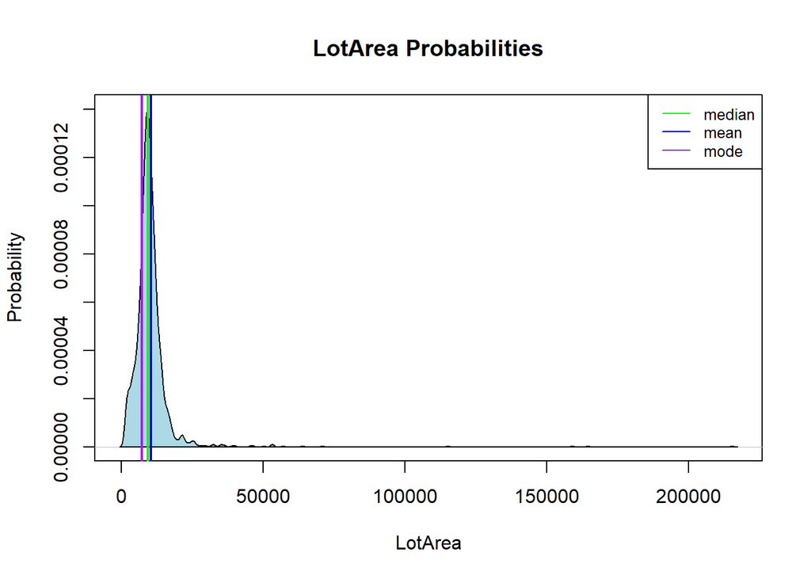

```r
#Create density plot for LotArea variable
d_LotArea <- density(train_df$LotArea)
plot(d_LotArea, main="LotArea Probabilities", ylab="Probability", xlab="LotArea")
polygon(d_LotArea, col="light blue")
abline(v = LotArea.median, col = "green", lwd = 2)
abline(v = LotArea.mean, col = "blue", lwd = 2)
abline(v = LotArea.mode, col = "purple", lwd = 2)
legend("topright", legend=c("median", "mean","mode"),col=c("green", "blue", "purple"), lty=1, cex=0.8)
```

### Variable Density Plots for SalePrice

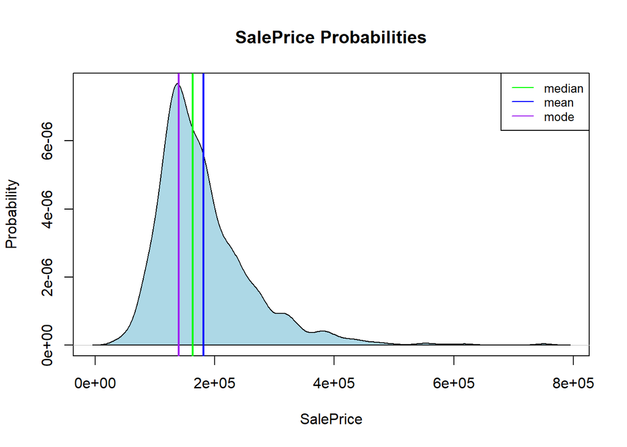

```r
#Create density plot for SalePrice variable.
SalePrice_for_graph <- density(train_df$SalePrice, na.rm=TRUE)
plot(SalePrice_for_graph, main="SalePrice Probabilities", ylab="Probability", xlab="SalePrice")
polygon(SalePrice_for_graph, col="light blue")
abline(v = SalePrice.median, col = "green", lwd = 2)
abline(v = SalePrice.mean, col = "blue", lwd = 2)
abline(v = SalePrice.mode, col = "purple", lwd = 2)
legend("topright", legend=c("median", "mean","mode"),col=c("green", "blue", "purple"), lty=1, cex=0.8 )
```

### Plotting A Graph

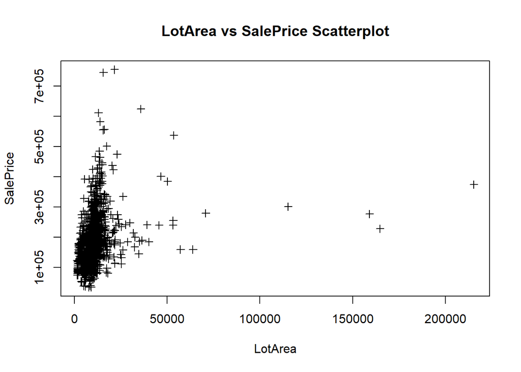

```r
plot(train_df$LotArea,train_df$SalePrice, main="LotArea vs SalePrice Scatterplot",
     xlab="LotArea", ylab="SalePrice", pch=3)
```

### 95% confidence Interval

Provide a 95% Confidence Interval for the difference in the mean of the variables.

```r
t.test(train_df$LotArea,train_df$SalePrice)
```

```
##
##  Welch Two Sample t-test
##
## data:  train_df$LotArea and train_df$SalePrice
## t = -81.321, df = 1505.1, p-value < 2.2e-16
## alternative hypothesis: true difference in means is not equal to 0
## 95 percent confidence interval:
##  -174514.7 -166294.1
## sample estimates:
## mean of x mean of y
##  10516.83 180921.20
```

Since the p value is too low, we reject the hypothesis that the difference in means is equal to 0.

### Correlation matrix

Derive a correlation matrix for THREE of the quantitative variables you selected.

```r
corMatrix<-cor(train_df[, which(names(train_df) %in% c("LotArea", "SalePrice", 'GrLivArea'))])
corMatrix
```

```
##             LotArea GrLivArea SalePrice
## LotArea   1.0000000 0.2631162 0.2638434
## GrLivArea 0.2631162 1.0000000 0.7086245
## SalePrice 0.2638434 0.7086245 1.0000000
```

Results show a very low but possible positive correlation between the data of 0.2638.

The correlation between GrLivArea and SalePrice seems to be high at 0.7086245

### Test the hypothesis using t-test

Test the hypothesis that the correlation between these variables is 0 and provide a 92% confidence interval.

```r
t.test(train_df$LotArea,train_df$SalePrice, conf.level=0.92)
```

```
##
##  Welch Two Sample t-test
##
## data:  train_df$LotArea and train_df$SalePrice
## t = -81.321, df = 1505.1, p-value < 2.2e-16
## alternative hypothesis: true difference in means is not equal to 0
## 92 percent confidence interval:
##  -174075.3 -166733.4
## sample estimates:
## mean of x mean of y
##  10516.83 180921.20
```

```r
t.test(train_df$LotArea,train_df$GrLivArea, conf.level=0.92)
```

```
##
##  Welch Two Sample t-test
##
## data:  train_df$LotArea and train_df$GrLivArea
## t = 34.411, df = 1467.1, p-value < 2.2e-16
## alternative hypothesis: true difference in means is not equal to 0
## 92 percent confidence interval:
##  8543.097 9459.632
## sample estimates:
## mean of x mean of y
## 10516.828  1515.464
```

```r
t.test(train_df$GrLivArea,train_df$SalePrice, conf.level=0.92)
```

```
##
##  Welch Two Sample t-test
##
## data:  train_df$GrLivArea and train_df$SalePrice
## t = -86.288, df = 1459.1, p-value < 2.2e-16
## alternative hypothesis: true difference in means is not equal to 0
## 92 percent confidence interval:
##  -183048.2 -175763.3
## sample estimates:
##  mean of x  mean of y
##   1515.464 180921.196
```

In all three cases the difference for the 3 variables’ means is not 0

### Would you be worried about familywise error? Why or why not?

The meaning of this result is that the variables do not say much about the final sale price.

### Linear Algebra and Correlation

Invert your correlation matrix (Precision matrix).

```r
corMatrixInverse <- ginv(corMatrix)
corMatrixInverse
```

```
##            [,1]       [,2]       [,3]
## [1,]  1.0884485 -0.1664868 -0.1692033
## [2,] -0.1664868  2.0340972 -1.3974846
## [3,] -0.1692033 -1.3974846  2.0349350
```

The diagonal elements represent variance inflation factors, which measures the relationship between combinations between variables.

### Multiplying the correlation matrix by the precision matrix.

This is the identity Matrix

```r
matrix1<- corMatrixInverse %*% corMatrix
matrix1
```

```
##           LotArea     GrLivArea     SalePrice
## [1,] 1.000000e+00 -2.498002e-16 -8.326673e-17
## [2,] 1.665335e-16  1.000000e+00  8.881784e-16
## [3,] 1.110223e-16 -4.440892e-16  1.000000e+00
```

### Multiply the precision matrix by the correlation matrix.

```r
matrix2<- corMatrix %*% corMatrixInverse
matrix2
```

```
##                   [,1]          [,2]         [,3]
## LotArea   1.000000e+00 -4.440892e-16 2.220446e-16
## GrLivArea 2.220446e-16  1.000000e+00 2.220446e-16
## SalePrice 2.498002e-16  0.000000e+00 1.000000e+00
```

### Performing Principle Components Analysis

```r
#Perform a log transform on each variable to normalize
dataCopy<-train_df
dataCopy$LotArea<-log(dataCopy$LotArea)
dataCopy$SalePrice<-log(dataCopy$SalePrice)
dataCopy$GrLivArea<-log(dataCopy$GrLivArea)

#apply PCA and ADD additional parameters for a more interesting interpretation

data.pca<-prcomp(dataCopy[, which(names(dataCopy) %in% c("LotArea", "SalePrice", "GrLivArea"))],center = TRUE,scale = TRUE)
data.pca
```

```
## Standard deviations (1, .., p=3):
## [1] 1.4246936 0.8370813 0.5191755
##
## Rotation (n x k) = (3 x 3):
##                 PC1        PC2         PC3
## LotArea   0.4746802  0.8799375  0.01971454
## GrLivArea 0.6204099 -0.3503987  0.70164972
## SalePrice 0.6243159 -0.3208281 -0.71224926
```

### Summary

```r
summary(data.pca)
```

```
## Importance of components:
##                           PC1    PC2     PC3
## Standard deviation     1.4247 0.8371 0.51918
## Proportion of Variance 0.6766 0.2336 0.08985
## Cumulative Proportion  0.6766 0.9102 1.00000
```

### Plotting PCA

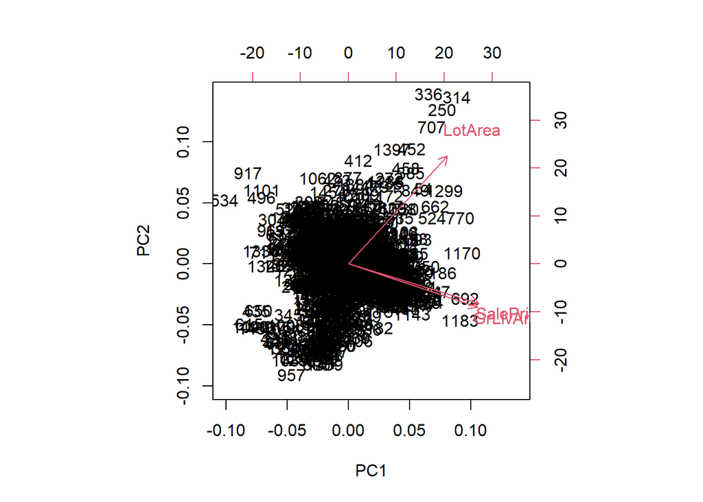

```r
biplot(data.pca)
```

### Analysis

Vectors that point in the same direction correspond to variables that have similar response profiles,

This can be interpreted as having similar meaning in the context set by the data,

Here SalePrice and GrLivArea have very similar vectors pointing to the same direction. where we will apply the regression technique.

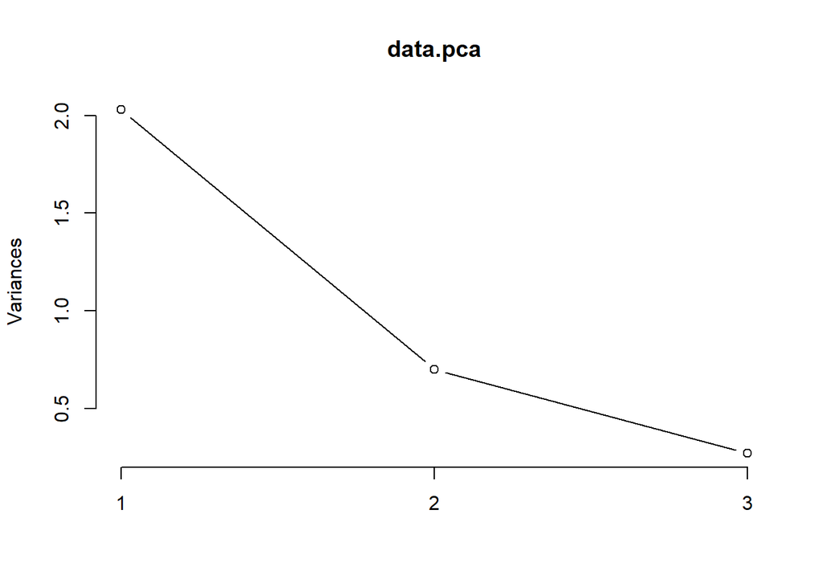

```r
screeplot(data.pca, type="lines")
```

### Calculus-Based Probability & Statistics

We take the LotArea data and fit it to an exponential function.

```r
lambda<-fitdistr(train_df$LotArea,"exponential")
lambda$estimate
```

```
##        rate
## 9.50857e-05
```

### #Transpose the rate into 1000 selected variables as an exponential distribution

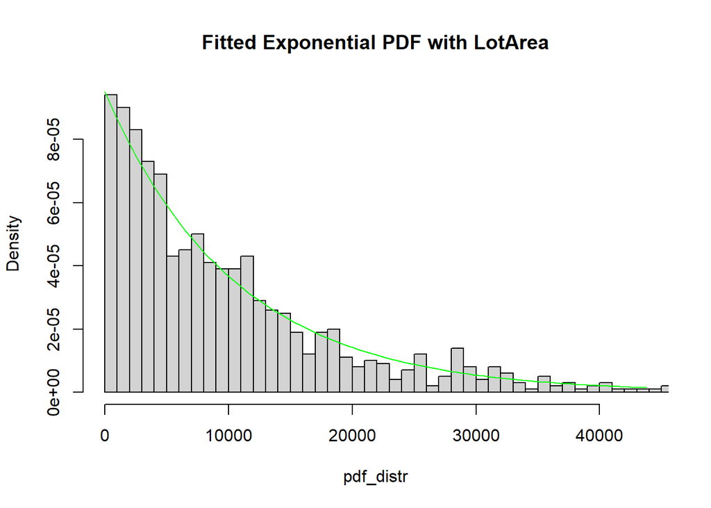

```r
pdf_distr<-rexp(1000, lambda$estimate)

#Plot the results of the exponential distribution
hist(pdf_distr, freq = FALSE, breaks = 100, main ="Fitted Exponential PDF with LotArea", xlim = c(1, quantile(pdf_distr, 0.99)))
curve(dexp(x, rate = lambda$estimate), col = "green", add = TRUE)
```

### Plotting the results as compared to the original data

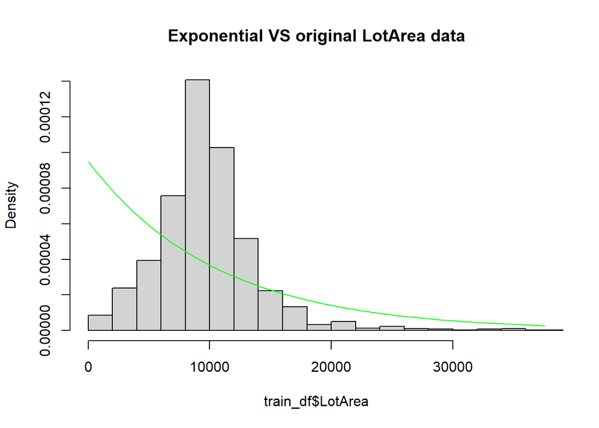

```r
hist(train_df$LotArea, freq = FALSE, breaks = 100, main ="Exponential VS original LotArea data",xlim = c(1, quantile(train_df$LotArea, 0.99)))
curve(dexp(x, rate = lambda$estimate), col = "green", add = TRUE)
```

### With the exponential PDF:

5th and 95th percentiles using the cumulative distribution function (CDF)

```r
qexp(0.05, rate = lambda$estimate, lower.tail = TRUE, log.p = FALSE)
```

```
## [1] 539.4428
```

```r
qexp(0.95, rate = lambda$estimate, lower.tail = TRUE, log.p = FALSE)
```

```
## [1] 31505.6
```

### 95% confidence interval from the empirical data, assuming normality

```r
qnorm(0.95,LotArea.mean, LotArea.sd)
```

```
## [1] 26934.55
```

### Empirical 5th percentile and 95th percentile of the data

```r
quantile(train_df$LotArea, c(.05, .95))
```

```
##       5%      95%
##  3311.70 17401.15
```

### What does these values mean?

Analyzing the above result we recognize the differences between a exponential equation and the selected right-skewed data.

The approximation can work to fit different models and help explain the data.

### Model Selection / Regression

```
##
## Call:
## lm(formula = train_df.train)
##
## Residuals:
##     Min      1Q  Median      3Q     Max
## -311457  -15589    -831   13665  273845
##
## Coefficients:
##                       Estimate Std. Error t value Pr(>|t|)
## (Intercept)         -5.193e+05  1.996e+05  -2.601 0.009392 **
## BldgType2fmCon      -2.050e+03  6.670e+03  -0.307 0.758600
## BldgTypeDuplex       5.642e+03  5.997e+03   0.941 0.346961
## BldgTypeTwnhs       -4.096e+04  6.790e+03  -6.032 2.10e-09 ***
## BldgTypeTwnhsE      -3.821e+04  4.290e+03  -8.907  < 2e-16 ***
## BsmtCondGd           3.527e+03  7.049e+03   0.500 0.616874
## BsmtCondPo           4.139e+04  2.604e+04   1.589 0.112207
## BsmtCondTA           5.689e+03  5.541e+03   1.027 0.304756
## BsmtExposureGd       2.218e+04  4.033e+03   5.500 4.54e-08 ***
## BsmtExposureMn      -9.737e+02  4.124e+03  -0.236 0.813384
## BsmtExposureNo      -8.296e+03  2.946e+03  -2.816 0.004932 **
## BsmtQualFa          -4.094e+04  8.292e+03  -4.937 8.92e-07 ***
## BsmtQualGd          -3.097e+04  4.414e+03  -7.015 3.64e-12 ***
## BsmtQualTA          -3.507e+04  5.407e+03  -6.485 1.24e-10 ***
## CentralAirY          2.649e+03  4.746e+03   0.558 0.576848
## GarageArea           1.402e+01  9.539e+00   1.470 0.141865
## GarageCars           1.028e+04  2.842e+03   3.618 0.000308 ***
## ExterQualFa         -2.298e+04  1.291e+04  -1.779 0.075430 .
## ExterQualGd         -1.854e+04  6.356e+03  -2.917 0.003591 **
## ExterQualTA         -2.377e+04  7.011e+03  -3.390 0.000719 ***
## Fireplaces           1.210e+04  1.717e+03   7.046 2.94e-12 ***
## FoundationCBlock     5.228e+03  4.166e+03   1.255 0.209713
## FoundationPConc      8.146e+03  4.621e+03   1.763 0.078152 .
## FoundationStone      1.273e+04  1.420e+04   0.896 0.370232
## FoundationWood       1.071e+04  1.994e+04   0.537 0.591206
## HouseStyle1.5Unf    -2.081e+04  9.418e+03  -2.210 0.027302 *
## HouseStyle1Story    -1.128e+04  3.594e+03  -3.139 0.001730 **
## HouseStyle2.5Fin     4.422e+04  1.266e+04   3.493 0.000493 ***
## HouseStyle2.5Unf     4.544e+03  1.091e+04   0.417 0.677108
## HouseStyle2Story    -1.960e+03  3.742e+03  -0.524 0.600613
```

[output cut: 42 more lines]

```
## RoofStyleHip         4.768e+03  1.124e+04   0.424 0.671411
## RoofStyleMansard     1.733e+04  1.698e+04   1.020 0.307775
## RoofStyleShed        3.800e+04  2.684e+04   1.416 0.157091
## YearBuilt            1.175e+02  8.670e+01   1.355 0.175574
## YearRemodAdd         2.018e+02  7.077e+01   2.851 0.004424 **
## ---
## Signif. codes:  0 '***' 0.001 '**' 0.01 '*' 0.05 '.' 0.1 ' ' 1
##
## Residual standard error: 32710 on 1337 degrees of freedom
##   (46 observations deleted due to missingness)
## Multiple R-squared:  0.8389, Adjusted R-squared:  0.8297
## F-statistic:  91.6 on 76 and 1337 DF,  p-value: < 2.2e-16
##
##    Min. 1st Qu.  Median    Mean 3rd Qu.    Max.
## -311457  -15589    -831       0   13665  273845
```

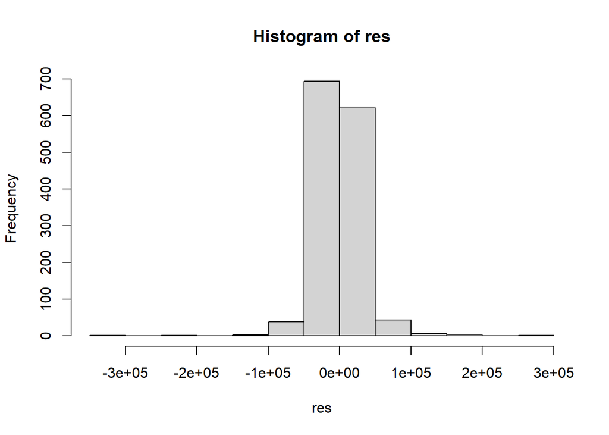

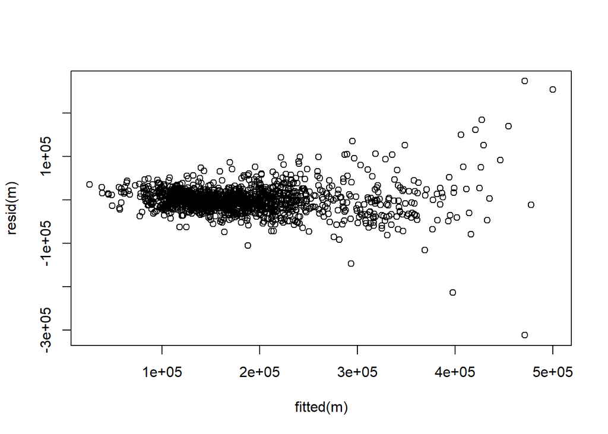

```r
check_model <- function(m) {
    print(summary(m))
    res = residuals(m)
    print(summary(res))
    hist(res)
    plot(fitted(m), resid(m))
}
par(mfrow = c(1, 1))

# Full training data set
train_df.train = train_df

# Reduce to Dataframe with selected feature sets
train_df.train = train_df.train %>% dplyr::select(SalePrice,
                                      BldgType,
                                      BsmtCond,
                                      BsmtExposure,
                                      BsmtQual,
                                      CentralAir,
                                      GarageArea,
                                      GarageCars,
                                      # Exterior1st,
                                      ExterQual,
                                      # Fence,
                                      Fireplaces,
                                      #FireplaceQu,
                                      Foundation,
                                      HouseStyle,
                                      KitchenQual,
                                      LandContour,
                                      LandSlope,
                                      LotArea,
                                      MasVnrArea,
                                      MiscVal,
                                      Neighborhood,
                                      OverallCond,
                                      OverallQual,
                                      PoolArea,
                                      # # PoolQC,
                                      RoofStyle,
                                      # # Street,
                                      YearBuilt,
                                      YearRemodAdd)
regr_model = lm(train_df.train)
check_model(regr_model)
```

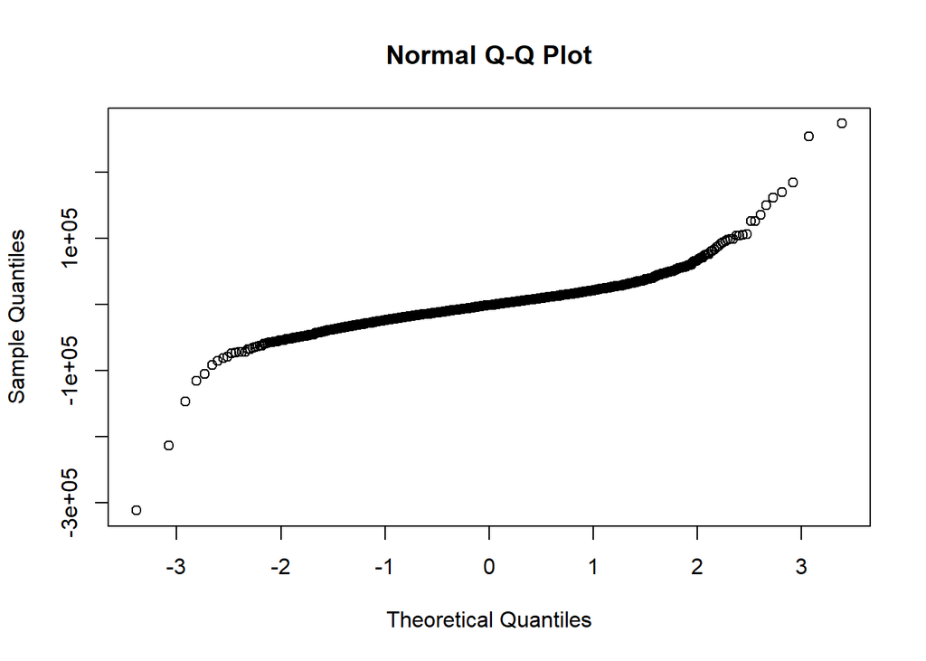

```r
qqnorm(residuals(regr_model))
```

```r
summary(train_df.train)
```

```
##    SalePrice        BldgType           BsmtCond         BsmtExposure
##  Min.   : 34900   Length:1460        Length:1460        Length:1460
##  1st Qu.:129975   Class :character   Class :character   Class :character
##  Median :163000   Mode  :character   Mode  :character   Mode  :character
##  Mean   :180921
##  3rd Qu.:214000
##  Max.   :755000
##
##    BsmtQual          CentralAir          GarageArea       GarageCars
##  Length:1460        Length:1460        Min.   :   0.0   Min.   :0.000
##  Class :character   Class :character   1st Qu.: 334.5   1st Qu.:1.000
##  Mode  :character   Mode  :character   Median : 480.0   Median :2.000
##                                        Mean   : 473.0   Mean   :1.767
##                                        3rd Qu.: 576.0   3rd Qu.:2.000
##                                        Max.   :1418.0   Max.   :4.000
##
##   ExterQual           Fireplaces     Foundation         HouseStyle
##  Length:1460        Min.   :0.000   Length:1460        Length:1460
##  Class :character   1st Qu.:0.000   Class :character   Class :character
##  Mode  :character   Median :1.000   Mode  :character   Mode  :character
##                     Mean   :0.613
##                     3rd Qu.:1.000
##                     Max.   :3.000
##
##  KitchenQual        LandContour         LandSlope            LotArea
##  Length:1460        Length:1460        Length:1460        Min.   :  1300
##  Class :character   Class :character   Class :character   1st Qu.:  7554
##  Mode  :character   Mode  :character   Mode  :character   Median :  9478
##                                                           Mean   : 10517
##                                                           3rd Qu.: 11602
##                                                           Max.   :215245
##
##    MasVnrArea        MiscVal         Neighborhood        OverallCond
##  Min.   :   0.0   Min.   :    0.00   Length:1460        Min.   :1.000
##  1st Qu.:   0.0   1st Qu.:    0.00   Class :character   1st Qu.:5.000
##  Median :   0.0   Median :    0.00   Mode  :character   Median :5.000
##  Mean   : 103.7   Mean   :   43.49                      Mean   :5.575
##  3rd Qu.: 166.0   3rd Qu.:    0.00                      3rd Qu.:6.000
##  Max.   :1600.0   Max.   :15500.00                      Max.   :9.000
##  NA's   :8
##   OverallQual        PoolArea        RoofStyle           YearBuilt
##  Min.   : 1.000   Min.   :  0.000   Length:1460        Min.   :1872
##  1st Qu.: 5.000   1st Qu.:  0.000   Class :character   1st Qu.:1954
##  Median : 6.000   Median :  0.000   Mode  :character   Median :1973
##  Mean   : 6.099   Mean   :  2.759                      Mean   :1971
##  3rd Qu.: 7.000   3rd Qu.:  0.000                      3rd Qu.:2000
##  Max.   :10.000   Max.   :738.000                      Max.   :2010
##
##   YearRemodAdd
##  Min.   :1950
##  1st Qu.:1967
##  Median :1994
##  Mean   :1985
##  3rd Qu.:2004
##  Max.   :2010
##
```

### Analysis:

Residual standard error: This is an estimate of the standard deviation of the residuals. In this case, it’s 32710, indicating the average difference between the observed values and the values predicted by the model is around 32710 units.

Multiple R-squared: This is the proportion of the variance in the dependent variable that is predictable from the independent variables. Here, it’s 0.8389, meaning approximately 83.89% of the variability in the dependent variable can be explained by the independent variables.

Adjusted R-squared: This is the R-squared value adjusted for the number of predictors in the model. It’s slightly lower at 0.8297 but still suggests a good fit.

F-statistic: This tests the overall significance of the regression model. A larger F-statistic with a small p-value suggests that the overall model is significant. Here, the F-statistic is 91.6 with a p-value less than 2.2e-16, indicating that the overall model is highly significant.

```r
test_df <- subset(test_df, select = -c(Alley, PoolQC, Fence, MiscFeature, FireplaceQu))
str(test_df)
```

```
## tibble [1,459 × 75] (S3: tbl_df/tbl/data.frame)
##  $ Id           : num [1:1459] 1461 1462 1463 1464 1465 ...
##  $ MSSubClass   : num [1:1459] 20 20 60 60 120 60 20 60 20 20 ...
##  $ MSZoning     : chr [1:1459] "RH" "RL" "RL" "RL" ...
##  $ LotFrontage  : num [1:1459] 80 81 74 78 43 75 NA 63 85 70 ...
##  $ LotArea      : num [1:1459] 11622 14267 13830 9978 5005 ...
##  $ Street       : chr [1:1459] "Pave" "Pave" "Pave" "Pave" ...
##  $ LotShape     : chr [1:1459] "Reg" "IR1" "IR1" "IR1" ...
##  $ LandContour  : chr [1:1459] "Lvl" "Lvl" "Lvl" "Lvl" ...
##  $ Utilities    : chr [1:1459] "AllPub" "AllPub" "AllPub" "AllPub" ...
##  $ LotConfig    : chr [1:1459] "Inside" "Corner" "Inside" "Inside" ...
##  $ LandSlope    : chr [1:1459] "Gtl" "Gtl" "Gtl" "Gtl" ...
##  $ Neighborhood : chr [1:1459] "NAmes" "NAmes" "Gilbert" "Gilbert" ...
##  $ Condition1   : chr [1:1459] "Feedr" "Norm" "Norm" "Norm" ...
##  $ Condition2   : chr [1:1459] "Norm" "Norm" "Norm" "Norm" ...
```

[output cut: 61 more lines]

### Second Model Selection / Regression Using Random Forest Model

```r
#select only numeric values
normalize <- function(train_df){
  subset <- select_if(train_df, is.numeric)
  subset[is.na(subset)] <- 0
  subset <- subset[complete.cases(subset),]
  return(subset)
}


trainMod <- normalize(train_df)
testMod <- normalize(test_df)
null <- lm(SalePrice~1, trainMod)
all <- glm(as.factor(SalePrice) ~ LotArea+GrLivArea, data=trainMod, family=binomial)
stepResults <- step(null, scope = list(lower = null, upper = all), direction = "both",trace = 0)

rfFit <-train(SalePrice ~.,
              data=trainMod,
              method="rf",
              trControl=trainControl(method="oob",number=5),
              prox=TRUE, importance = TRUE,
              allowParallel=TRUE)

# show the model summary
rfFit
```

```
## Random Forest
##
## 1460 samples
##   37 predictor
##
## No pre-processing
## Resampling results across tuning parameters:
##
##   mtry  RMSE      Rsquared
##    2    31543.92  0.8422305
##   19    29313.53  0.8637527
##   37    29874.85  0.8584848
##
## RMSE was used to select the optimal model using the smallest value.
## The final value used for the model was mtry = 19.
```

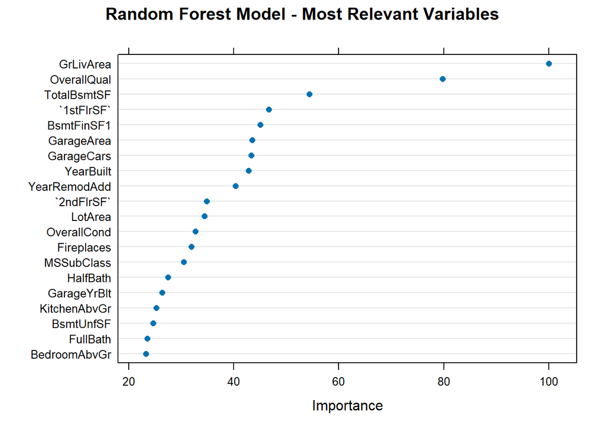

```r
# display the variables determined to be the most relevant
dotPlot(varImp(rfFit), main = "Random Forest Model - Most Relevant Variables")
```

### Predition

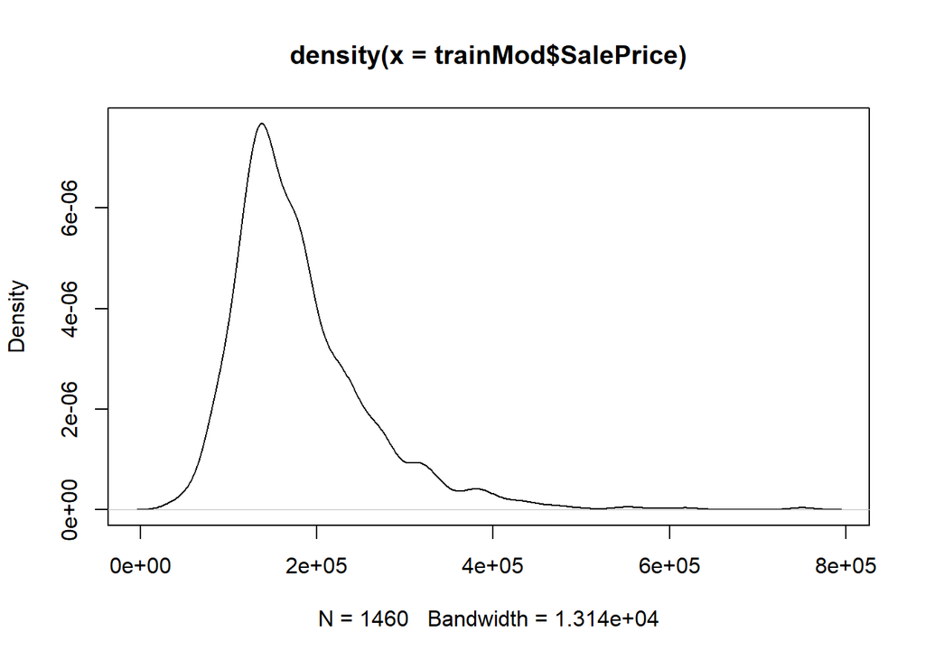

```r
#append scored data

result <- data.frame('Id' = testMod$Id,'SalePrice' = predict(rfFit, testMod))
result$SalePrice[result$SalePrice<0] <- 0

plot(density(trainMod$SalePrice))
```

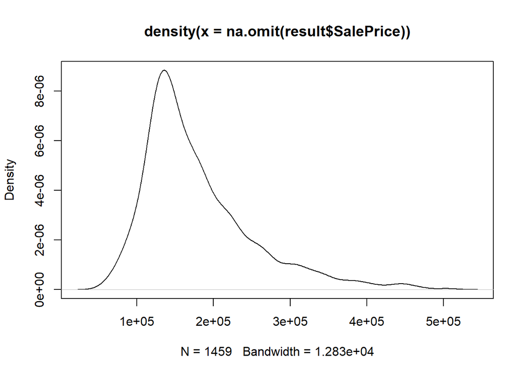

```r
plot(density(na.omit(result$SalePrice)))
```

### Save the results to send to Kaggle

```r
write.csv(result, file = "results_for_kaggle.csv",row.names=FALSE)
```